# PSA Cancer - Previsão

Arthur Sena

03/26/2016

# Descrição dos Dados

Os dados utilizados neste problema são referentes a exames em pacientes homens afim de identificar sintomas de câncer de prostata. O dataset é composto por dez variáveis, onde uma delas (psa) será considerada nossa variável resposta. Nosso objetivo final será predizer a variável psa a partir dos preditores disponíveis utilizando o algoritmo de **regressão linear**. Abaixo é possível ver uma amostra dos nossos dados.

```r
    library(dplyr)
    library(caret)
    require(reshape2)
    require(ggplot2)
    data <- read.delim("~/Documents/DataAnalysis_Problems/DataCourse2/Problem3/data.txt")
    data <- data %>% select(-X)
    print(head(data))
```

```
##       lcavol  lweight age      lbph svi       lcp gleason pgg45       lpsa
## 1 -0.5798185 2.769459  50 -1.386294   0 -1.386294       6     0 -0.4307829
## 2 -0.9942523 3.319626  58 -1.386294   0 -1.386294       6     0 -0.1625189
## 3 -0.5108256 2.691243  74 -1.386294   0 -1.386294       7    20 -0.1625189
## 4 -1.2039728 3.282789  58 -1.386294   0 -1.386294       6     0 -0.1625189
## 5  0.7514161 3.432373  62 -1.386294   0 -1.386294       6     0  0.3715636
## 6 -1.0498221 3.228826  50 -1.386294   0 -1.386294       6     0  0.7654678
##   train
## 1  TRUE
## 2  TRUE
## 3  TRUE
## 4  TRUE
## 5  TRUE
## 6  TRUE
```

As nossa variáveis preditoras estão descritas logo abaixo:

- **vol**: volume do câncer
- **idade**: idade do paciente
- **hpb**: hiperplasia prostática benigna
- **ivs**: invasão das vesículas seminais
- **pc**: penetração capsular
- **gleason**: escore Gleason
- **pgg45**: percentagem escore Gleason 4 ou 5
- **psa**: antígeno específico da próstata (esta é a variável resposta).

Antes de construir qualquer modelo, vamos primeiro examinar a distribuição das nossas variáveis e a correlação das mesmas com a nossa variavel resposta.

### Sumario

```r
    summary(data)
```

```
##      lcavol           lweight           age             lbph
##  Min.   :-1.3471   Min.   :2.375   Min.   :41.00   Min.   :-1.3863
##  1st Qu.: 0.5128   1st Qu.:3.376   1st Qu.:60.00   1st Qu.:-1.3863
##  Median : 1.4469   Median :3.623   Median :65.00   Median : 0.3001
##  Mean   : 1.3500   Mean   :3.629   Mean   :63.87   Mean   : 0.1004
##  3rd Qu.: 2.1270   3rd Qu.:3.876   3rd Qu.:68.00   3rd Qu.: 1.5581
##  Max.   : 3.8210   Max.   :4.780   Max.   :79.00   Max.   : 2.3263
##       svi              lcp             gleason          pgg45
##  Min.   :0.0000   Min.   :-1.3863   Min.   :6.000   Min.   :  0.00
##  1st Qu.:0.0000   1st Qu.:-1.3863   1st Qu.:6.000   1st Qu.:  0.00
##  Median :0.0000   Median :-0.7985   Median :7.000   Median : 15.00
##  Mean   :0.2165   Mean   :-0.1794   Mean   :6.753   Mean   : 24.38
##  3rd Qu.:0.0000   3rd Qu.: 1.1787   3rd Qu.:7.000   3rd Qu.: 40.00
##  Max.   :1.0000   Max.   : 2.9042   Max.   :9.000   Max.   :100.00
##       lpsa           train
##  Min.   :-0.4308   Mode :logical
##  1st Qu.: 1.7317   FALSE:30
##  Median : 2.5915   TRUE :67
##  Mean   : 2.4784   NA's :0
##  3rd Qu.: 3.0564
##  Max.   : 5.5829
```

### Distribuição

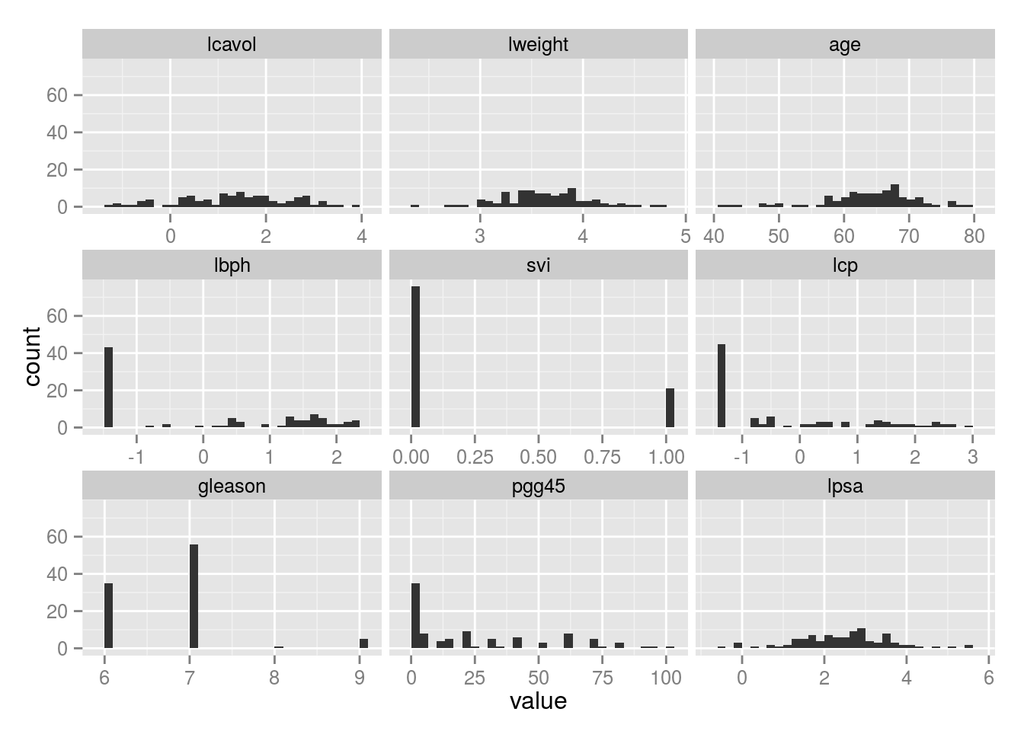

```r
   df <- melt(data)
   ggplot(df,aes(x = value)) +
    facet_wrap(~variable, scales = "free_x") +
    geom_histogram()
```

### Correlação

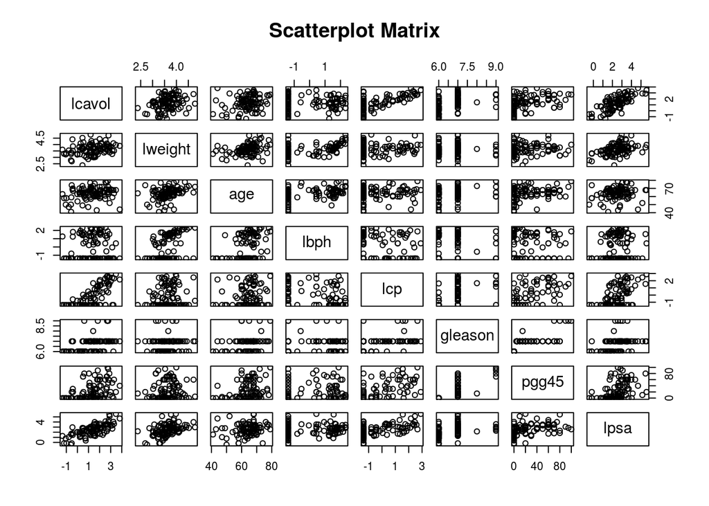

```r
   pairs(~.,data=select(data, -train, -svi),main="Scatterplot Matrix")
```

```r
   temp <- cor(select(data,-train))
   print(temp)
```

```
##            lcavol    lweight       age         lbph         svi
## lcavol  1.0000000 0.28052138 0.2249999  0.027349703  0.53884500
## lweight 0.2805214 1.00000000 0.3479691  0.442264399  0.15538490
## age     0.2249999 0.34796911 1.0000000  0.350185896  0.11765804
## lbph    0.0273497 0.44226440 0.3501859  1.000000000 -0.08584324
## svi     0.5388450 0.15538490 0.1176580 -0.085843238  1.00000000
## lcp     0.6753105 0.16453714 0.1276678 -0.006999431  0.67311118
## gleason 0.4324171 0.05688209 0.2688916  0.077820447  0.32041222
## pgg45   0.4336522 0.10735379 0.2761124  0.078460018  0.45764762
## lpsa    0.7344603 0.43331938 0.1695928  0.179809404  0.56621822
##                  lcp    gleason      pgg45      lpsa
## lcavol   0.675310484 0.43241706 0.43365225 0.7344603
## lweight  0.164537142 0.05688209 0.10735379 0.4333194
## age      0.127667752 0.26889160 0.27611245 0.1695928
## lbph    -0.006999431 0.07782045 0.07846002 0.1798094
## svi      0.673111185 0.32041222 0.45764762 0.5662182
## lcp      1.000000000 0.51483006 0.63152825 0.5488132
## gleason  0.514830063 1.00000000 0.75190451 0.3689868
## pgg45    0.631528246 0.75190451 1.00000000 0.4223159
## lpsa     0.548813175 0.36898681 0.42231586 1.0000000
```

Analisando a matrix e gráfico de correlação acima podemos escolher variáveis que apresentam uma correlação mais forte com o PSA, porém temos que ficar atentos a preditores que tem correlação forte entre si, já que eles podem atrapalhar o modelo.

```r
   temp <- as.data.frame(temp)
   temp <- select(temp, lpsa)
   print(temp)
```

```
##              lpsa
## lcavol  0.7344603
## lweight 0.4333194
## age     0.1695928
## lbph    0.1798094
## svi     0.5662182
## lcp     0.5488132
## gleason 0.3689868
## pgg45   0.4223159
## lpsa    1.0000000
```

Analisando os dados acima, vamos remover as variáveis ‘Age’ e ‘Lbph’ pois tem correlação baixa com o PSA. Em compensação vemos que a variável ‘lcavol’ é a que apresenta a maior correlação (0.7344603). O gráfico abaixo evidencia mais tal correlação mostrando que os dados apresentam uma forma linear.

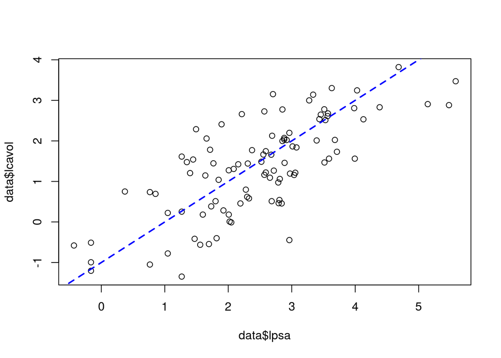

```r
   plot(data$lpsa, data$lcavol)
   abline(-1,1,col="blue",lty=2,lwd=2)
```

# Construindo Modelo

```r
   data <- select(data, -age , -lbph)
    train <- filter(data, train == TRUE)
    test <- filter(data, train == FALSE)
    reg_linear <- lm(lpsa~., data = select(train , -train))
    summary(reg_linear)
```

```
##
## Call:
## lm(formula = lpsa ~ ., data = select(train, -train))
##
## Residuals:
##      Min       1Q   Median       3Q      Max
## -1.52463 -0.35992 -0.03931  0.43510  1.50828
##
## Coefficients:
##              Estimate Std. Error t value Pr(>|t|)
## (Intercept) -0.953469   1.474564  -0.647 0.520349
## lcavol       0.576004   0.109431   5.264    2e-06 ***
## lweight      0.734888   0.200029   3.674 0.000511 ***
## svi          0.636620   0.301430   2.112 0.038859 *
## lcp         -0.212480   0.112866  -1.883 0.064608 .
## gleason     -0.066688   0.199999  -0.333 0.739964
## pgg45        0.009339   0.005597   1.668 0.100452
## ---
## Signif. codes:  0 '***' 0.001 '**' 0.01 '*' 0.05 '.' 0.1 ' ' 1
##
## Residual standard error: 0.7321 on 60 degrees of freedom
## Multiple R-squared:  0.666,  Adjusted R-squared:  0.6326
## F-statistic: 19.94 on 6 and 60 DF,  p-value: 1.172e-12
```

Percebos que as variáveis ‘pgg45’ e ‘gleason’ apresetaram um p-valor alto, ou seja, elas não são boas preditoras nesse modelo. Vamos agora realizar nossa predição.

# Predição

```r
   predicoes = predict.lm(reg_linear,select(test , -train, -lpsa))
   residuos = test$lpsa - predicoes
```

# RMSE e R2

```r
   RMSE(predicoes, test$lpsa)
```

```
## [1] 0.7226102
```

```r
   R2(predicoes, test$lpsa)
```

```
## [1] 0.51667
```

RMSE indica o quão acurado nosso modelo se comportou e o R2 sinaliza o quão bem nossa variável resposta pode ser explica pelo nosso modelo. Vemos que apresentamos um RMSE e R2, relativamente, altos. Porém, é importante visualizar nossas predições a fim de ter uma melhor noção do desempenho do modelo.

# Gráficos de Diagnóstico

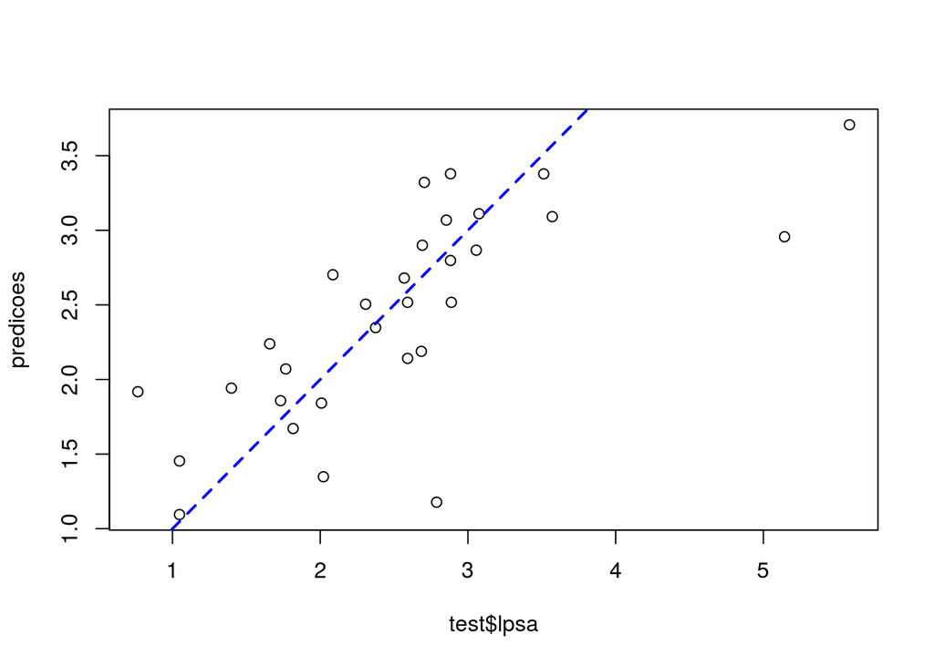

```r
   axisRange = extendrange(c(test$lpsa,predicoes)) #deixando as variáveis na mesma escala
    plot(test$lpsa,predicoes)
    abline(0,1,col="blue",lty=2,lwd=2)
```

Podemos notar alguns outlier’s na nossa variável resposta. Muito provavelmente, eles influenciaram no calculo do R2 e RMSE. Sem eles, poderíamos ter obtidos melhores valores para tais métricas.

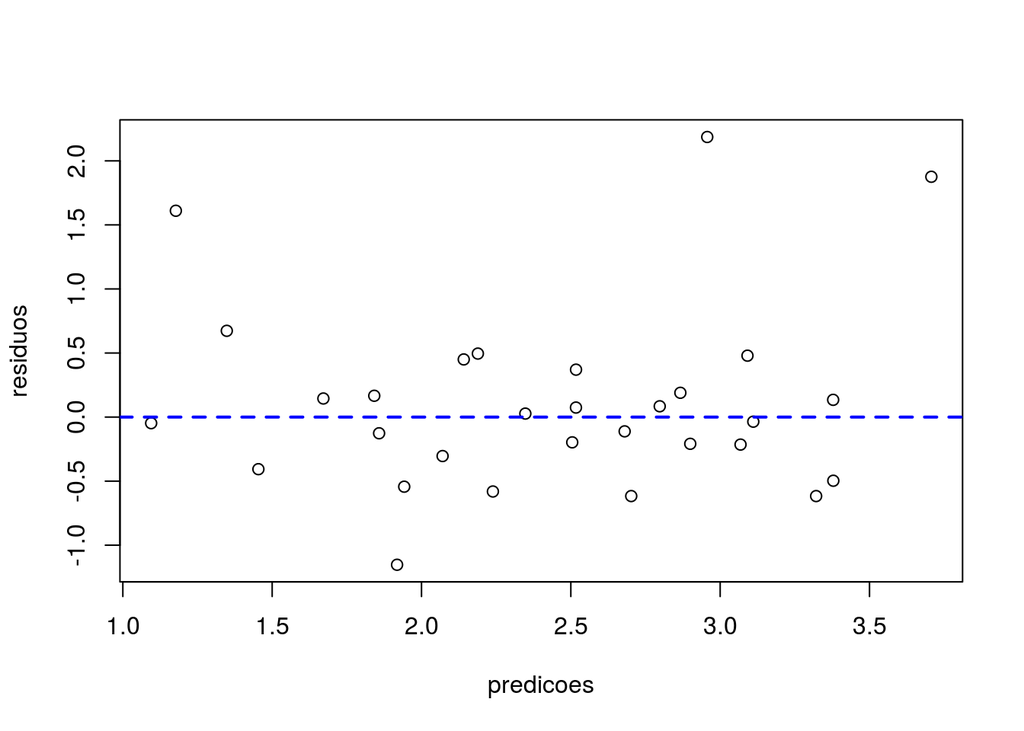

```r
   plot(predicoes,residuos)
   abline(h=0,col="blue",lty=2,lwd=2)
```

No gráfico de resíduos é importante que não seja possível visualizar nenhum padrão o que podemos constatar observando a visualização acima.